# Noncoding RNA Set Cis Annotation and Enrichment

[NoRCE](https://github.com/guldenolgun) package systematically performs annotation and enrichment analysis for a set of regulatory non-coding RNA genes. NoRCE analyses are based on spatially proximal mRNAs at a certain distance for a set of non-coding RNA genes or regions of interest. Moreover, specific analyses such as biotype selection, miRNA-mRNA co-expression, miRNA-mRNA target prediction can be performed for filtering. Besides, it allows to curate the gene set according to the topologically associating domain (TAD) regions. Work flow of the package can be seen below:

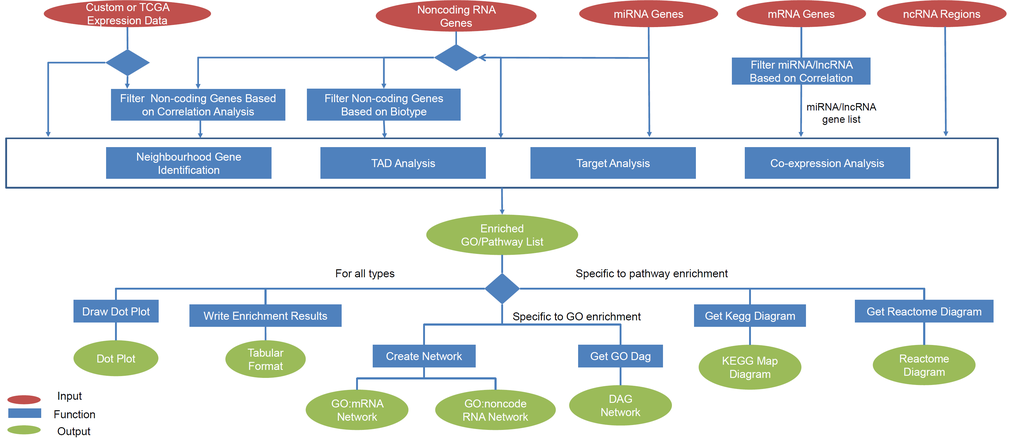

## Supported Assemblies and Organisms

- *Homo Sapiens (hg19 and hg38)*
- *Mus Musculus (mm10)*
- *Rattus Norvegicus (rn6)*
- *Drosophila Melanogaster (dm6)*
- *Danio Rerio (danRer10)*
- *Caenorhabditis Elegans (ce11)*
- *Saccharomyces Cerevisiae (sc3)*

# GO Enrichment Analysis

GO enrichment analysis can be performed based on gene neigbourhood, predicted targets, co-expression values and/or topological domain analysis. HUGO, ENSEMBL gene, ENSEMBL transcript gene, ENTREZ ID and miRBase names are supported formats for the input gene list. Moreover, NoRCE accepts a list of genomic regions. The input genomic region list should be in a .bed format. Each analysis is controlled by corresponding parameters. When related parameters are set, the gene set resulting from the intersection of those analysis will be considered for enrichment analysis (Co-expression analysis can be augmented with other analysis). GO enrichment analysis are carried out with `geneGOEnricher` and `geneRegionGOEnricher` functions. Also, miRNA gene enrichment are carried out with `mirnaGOEnricher` and `mirnaRegionGOEnricher` functions. The subset of the GO-terms called GO-slims can be used for annotation and enrichment. Species assembly must be defined using the `hg` parameter. NoRCE allows the user to use background gene set. The background gene set and the format of the gene set should be defined.

### Enrichment Analysis Based on Gene Neighbourhood

When the `near` parameter is set to `TRUE`, the closest genes for the input gene list are retrieved. The gene neighbourhood taken into consideration is controlled by the `upstream` and `downstream` parameters. By default, all genes that fall into 10 kb upstream and downstream of the input genes are retrieved. Also, using `searchRegion` parameter, the analysis can be performed for only those genes whose exon or intron regions fall into the specified upstream and downstream range of the input genes.

```r
library(NoRCE)
```

Moreover, [NoRCE](https://github.com/guldenolgun) can convert .txt file or data frame to a .bed formatted file to make it available for region based analysis.

```r
#txt formatted data
data("ncRegion")

#Write data to a txt file
write.table(ncRegion,paste("ncRegion.txt"),sep = '\t',row.names = FALSE,col.names = FALSE)

#Convert txt file that just created to bed formatted data
regionNC<-readbed("ncRegion.txt")
```

```r
data("ncRegion")

#Convert dataframe to bed formatted data
regionNC <-  readbed(dm_file = ncRegion,isText = FALSE)


#Perform enrichment based on neighourhood of non-coding RNA region
regionGO<-geneRegionGOEnricher(region = regionNC, hg= 'hg38', near = TRUE)
```